# English proficiency and study-abroad attitudes

## More mediation models

The relationship between test scores, English confidence, and stress is interesting, but perhaps we can dig a little deeper. It makes sense that an objective measure of English ability such as IELTS / TOEFL would be abstracted into a psychological measure - English confidence - in order to be associated with the psychological measure of stress. But is there another factor that mediates the relationship between English confidence and stress? How does English confidence translate into lower stress levels - through potential coping mechanisms? One possible factor is that it is associated with greater social interaction, which in turn ameliorates stress levels.

First let’s see if English confidence is predictive of likelihood / frequency of interaction with native friends, as measured on a 5-point Likert scale. This dependent measure is an ordinal scale variable so we’ll use an ordered logit model. We’ll also plot the data with a linear regression line for reference.

```r
refiltered$friends_factor <- factor(refiltered$native_friends)
friends <- polr(friends_factor ~ english_confidence + sex + traveled_before, data = refiltered, Hess = TRUE)
coefs <- coef(summary(friends))
ps <- pnorm(abs(coefs[,'t value']), lower.tail = FALSE) * 2
ptable <- cbind(coefs, "p value" = ps)
ptable
```

```
##                                  Value Std. Error   t value      p value
## english_confidence           0.2494812 0.03356325 7.4331679 1.060272e-13
## sexFemale                    0.1071153 0.20012421 0.5352442 5.924810e-01
## traveled_beforeAbroad before 0.2899027 0.21121069 1.3725760 1.698842e-01
## 1|2                          1.7029766 0.46434792 3.6674583 2.449734e-04
## 2|3                          2.8395530 0.47083143 6.0309333 1.630154e-09
## 3|4                          4.1203471 0.49686704 8.2926553 1.107479e-16
## 4|5                          4.7617233 0.51300324 9.2820532 1.662436e-20
```

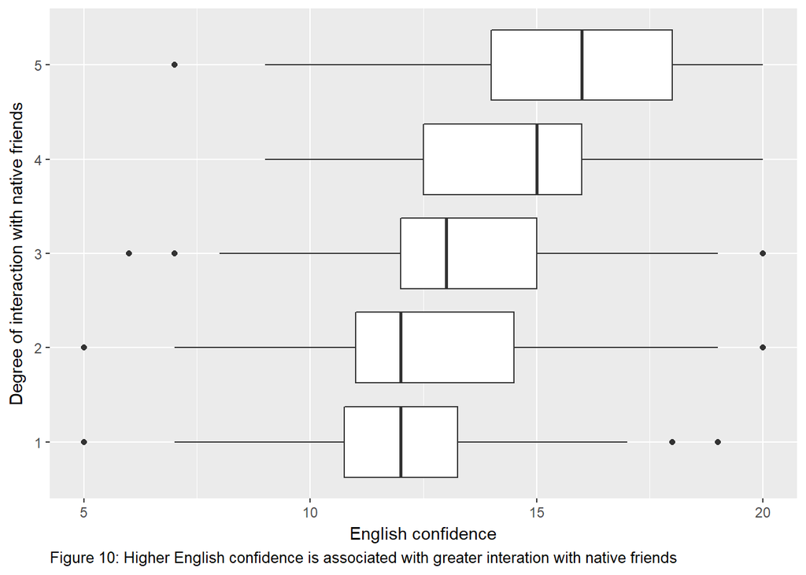

```r
ggplot(refiltered, aes(x=friends_factor, y=english_confidence)) + geom_boxplot() +  labs(x="Degree of interaction with native friends", y="English confidence", caption = "Figure 10: Higher English confidence is associated with greater interation with native friends") +  theme(plot.caption=element_text(hjust=0)) + coord_flip()
```

So it looks like there’s a significant relationship between English confidence and social interaction with natives - a 1 unit increase in English confidence is associated with .25 log odds increase in probability of a higher reported value on the likert scale of social interaction. Next we’ll see if social interaction is related to stress levels.

```r
Anova(lm(stress ~ friends_factor + traveled_before + sex, data = refiltered), type = "III")
```

```
## Anova Table (Type III tests)
##
## Response: stress
##                 Sum Sq  Df  F value    Pr(>F)
## (Intercept)     189861   1 763.4993 < 2.2e-16 ***
## friends_factor    8787   4   8.8338 8.335e-07 ***
## traveled_before    723   1   2.9061   0.08913 .
## sex                 31   1   0.1230   0.72606
## Residuals        87284 351
## ---
## Signif. codes:  0 '***' 0.001 '**' 0.01 '*' 0.05 '.' 0.1 ' ' 1
```

Looks like interaction with friends is very significantly predictive of stress levels. Let’s plot the relationship.

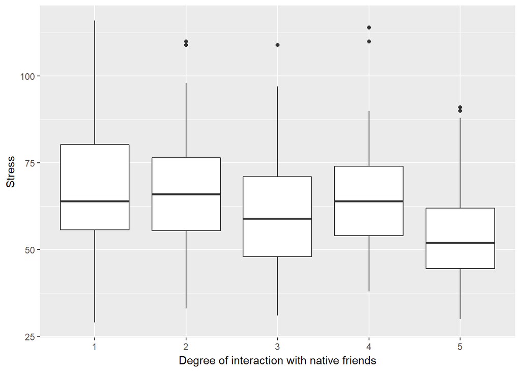

```r
ggplot(refiltered, aes(x=friends_factor, y=stress)) + geom_boxplot() + labs(x="Degree of interaction with native friends", y="Stress")
```

We now have pretty good reason to believe social interaction with friends might mediate the relationship between English confidence and stress levels. Let’s run the mediation analysis.

```r
m <- friends
y <- lm(stress ~ friends_factor + english_confidence + sex + traveled_before, data=refiltered)
med_conf_friends_stress <- mediate(m, y, sims = 100, boot = TRUE, mediator = "friends_factor", treat = "english_confidence", control.value = 12, treat.value = 13)
summary(med_conf_friends_stress)
```

```
##
## Causal Mediation Analysis
##
## Nonparametric Bootstrap Confidence Intervals with the Percentile Method
##
##                Estimate 95% CI Lower 95% CI Upper p-value
## ACME             -0.799       -1.099         0.21    0.12
## ADE              -0.330       -0.866         0.22    0.28
## Total Effect     -1.130       -1.582         0.10    0.08 .
## Prop. Mediated    0.708       -0.362         2.83    0.08 .
## ---
## Signif. codes:  0 '***' 0.001 '**' 0.01 '*' 0.05 '.' 0.1 ' ' 1
##
## Sample Size Used: 358
##
##
## Simulations: 100
```

The mediation analysis using the ordered logit model doesn’t correspond well with our intuitive sense of the data, with English confidence related to social interaction, which is related to stress. Indeed, adding social interaction to the model predicting stress makes English confidence no longer significant, strongly suggesting a mediated effect:

```r
Anova(y, type = "III")
```

```
## Anova Table (Type III tests)
##
## Response: stress
##                    Sum Sq  Df  F value    Pr(>F)
## (Intercept)         70602   1 284.1649 < 2.2e-16 ***
## friends_factor       6726   4   6.7682 2.951e-05 ***
## english_confidence    325   1   1.3089    0.2534
## sex                    29   1   0.1150    0.7347
## traveled_before       651   1   2.6193    0.1065
## Residuals           86959 350
## ---
## Signif. codes:  0 '***' 0.001 '**' 0.01 '*' 0.05 '.' 0.1 ' ' 1
```

Perhaps this is due to our use of the ordered logit model, meaning the coefficients don’t combine well to form the `a*b` indirect effect in the mediation analysis, because one is on the log-odds scale (the model with the mediator as the dependent measure) and one is on the linear scale (the model with stress as the dependent measure). Let’s refit the former on a linear scale - as is sometimes done when analyzing a likert scale - and see how our mediation analysis turns out. We’ll repolot the relationship between social interaction and stress as a linear trend for good measure.

```r
m <- lm(native_friends ~ english_confidence + sex + traveled_before, data = refiltered)
summary(m)
```

```
##
## Call:
## lm(formula = native_friends ~ english_confidence + sex + traveled_before,
##     data = refiltered)
##
## Residuals:
##      Min       1Q   Median       3Q      Max
## -2.99380 -0.93707  0.04039  1.02438  3.07458
##
## Coefficients:
##                              Estimate Std. Error t value Pr(>|t|)
## (Intercept)                   0.60977    0.31806   1.917    0.056 .
## english_confidence            0.17236    0.02161   7.975 2.14e-14 ***
## sexFemale                     0.10910    0.14527   0.751    0.453
## traveled_beforeAbroad before  0.25892    0.14941   1.733    0.084 .
## ---
## Signif. codes:  0 '***' 0.001 '**' 0.01 '*' 0.05 '.' 0.1 ' ' 1
##
## Residual standard error: 1.288 on 354 degrees of freedom
## Multiple R-squared:  0.1684, Adjusted R-squared:  0.1614
## F-statistic:  23.9 on 3 and 354 DF,  p-value: 4.151e-14
```

```r
y <- lm(stress ~ native_friends + english_confidence + sex + traveled_before, data = refiltered)
med_conf_friends_stress_linear <- mediate(m, y, sims = 100, boot = TRUE, mediator = "native_friends", treat = "english_confidence", control.value = 12, treat.value = 13)
summary(med_conf_friends_stress_linear)
```

```
##
## Causal Mediation Analysis
##
## Nonparametric Bootstrap Confidence Intervals with the Percentile Method
##
##                Estimate 95% CI Lower 95% CI Upper p-value
## ACME             -0.484       -0.764        -0.27  <2e-16 ***
## ADE              -0.336       -0.877         0.14    0.22
## Total Effect     -0.820       -1.304        -0.34  <2e-16 ***
## Prop. Mediated    0.590        0.290         1.33  <2e-16 ***
## ---
## Signif. codes:  0 '***' 0.001 '**' 0.01 '*' 0.05 '.' 0.1 ' ' 1
##
## Sample Size Used: 358
##
##
## Simulations: 100
```

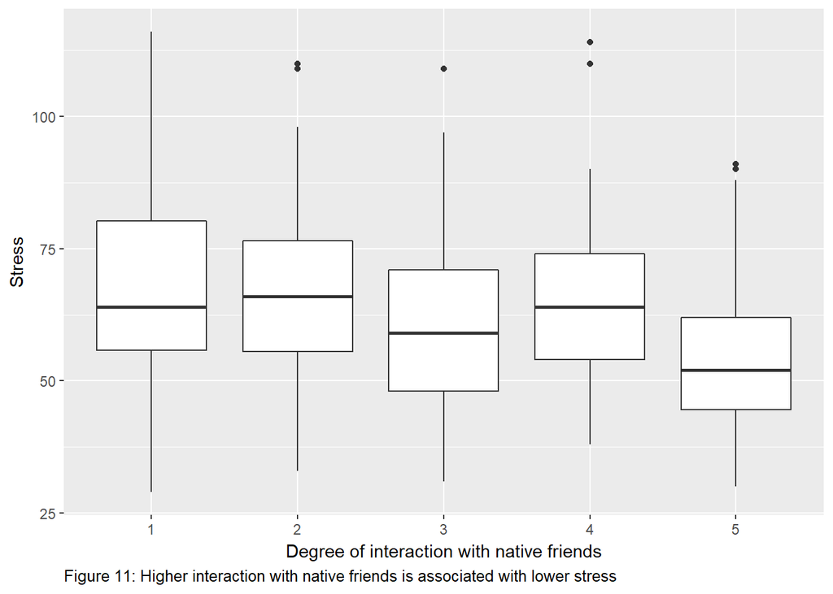

```r
ggplot(refiltered, aes(x=friends_factor, y=stress)) + geom_boxplot() + geom_smooth(method="lm") + labs(x="Degree of interaction with native friends", y="Stress", caption = "Figure 11: Higher interaction with native friends is associated with lower stress") +  theme(plot.caption=element_text(hjust=0))
```

So using the linear models we have evidence of an ACME: the relationship between English confidence and stress is mediated by degree of social interaction with native friends. Finally, let’s output this model to a table.

```r
htmlreg(list(m,y), type = "html",  digits = 3, bold = .05, booktabs = TRUE, sideways = FALSE, use.packages = FALSE, single.row = FALSE, custom.model.names =c('Mediator: Native friends', 'Stress'), leading.zero = TRUE, stars = c(0.05, 0.01, 0.001), custom.note = "\\parbox{.4\\linewidth}{\\vspace{2pt}%stars. \\\\Results are as coefficient (standard error).}",  include.nobs = TRUE, include.adjrs = TRUE, include.fstatistic = FALSE, include.rmse = FALSE, custom.coef.map = list('(Intercept)' = '(Constant)', "english_confidence" = "$a$, \\textit{c'}: English confidence", 'native_friends' = "$b$: Native friends", 'sexFemale' = 'Gender (Female)', 'traveled_beforeAbroad before' = 'Prior travel'), caption = "Interaction with native friends mediates the relationship between English confidence and stress. $ab$ = -0.484. 95\\% confidence interval: [-0.76, -0.24], \\textit{p} < $10^{-16}$")
```

|  | **Mediator: Native friends** | **Stress** |
| --- | --- | --- |
| (Constant) | 0.610 | **77.206***** |
|  | (0.318) | (3.944) |
| $a$, : English confidence | **0.172***** | -0.336 |
|  | (0.022) | (0.290) |
| $b$: Native friends |  | **-2.806***** |
|  |  | (0.656) |
| Gender (Female) | 0.109 | -1.588 |
|  | (0.145) | (1.793) |
| Prior travel | 0.259 | -2.935 |
|  | (0.149) | (1.851) |
| R<sup>2</sup> | 0.168 | 0.089 |
| Adj. R<sup>2</sup> | 0.161 | 0.079 |
| Num. obs. | 358 | 358 |

## Multiple mediator model

We now have 2 conceptual mediation models:

- Test scores -> English confidence -> stress
- English confidence -> native friends -> stress

What we want to do now is see if we can combine these models, using a multi-mediator approach:

- Test scores -> English confidence -> native friends -> stress

That is, we want to test if the effect of test scores is mediated by English confidence, the effect of which is mediated by social interaction, in a single statistical model that accounts for all possible sub-model paths such as:

- Test scores -> stress
- Test scores -> English confidence -> stress
- Test scores -> English confidence -> native friends -> stress
- Test scores -> native friends -> stress

We can’t perform multiple serial/parallel mediation analysis using a continuous treatment variable as ours, test scores, is using the `medation` package in R, so we’ll export the data frame to SPSS. We’ll rename a few variables first to make our output in SPSS more readable because the PROCESS macro in SPSS does not allow for long variable names.

```r
#refiltered %>% rename(confidence = english_confidence, test_scores_less_trimmed_numeric = overall_score_numeric_less_trimmed) %>% write.foreign("C:/Users/ajame/Dropbox/English_stress/english_stress.txt", "C:/Users/ajame/Dropbox/English_stress/english_stress.sps", package="SPSS")
```

The output of these analyses are found in multiple_mediators.htm. Bootstrap estimation of confidence intervals indicates that the the paths in **bold** below are statistically significant:

- Test scores -> stress
- Test scores -> English confidence -> stress
- **Test scores -> English confidence -> native friends -> stress**
- **Test scores -> native friends -> stress**

Thus, there is no direct effect of test scores on stress, but test sccores act indirectly on stress through its influence on engagement with native friends, and through its influence on English confidence which in turn afffects native friendships which in serial affects stress. Both paths have negative coefficients, such that higher test scores are associated with lower stress indirectly through mediator variables.

We will use R to generate the associated regression output table in LaTeX format though.

```r
m1_confidence <- lm(english_confidence ~ overall_score_numeric_less_trimmed + sex + traveled_before, data = refiltered)
m2_friends <- lm(native_friends ~ overall_score_numeric_less_trimmed + english_confidence + sex + traveled_before, data = refiltered)
y <- lm(stress ~ overall_score_numeric_less_trimmed + english_confidence + native_friends + sex + traveled_before, data = refiltered)
```

```r
htmlreg(list(m1_confidence, m2_friends, y), type = "html",  digits = 3, bold = .05, booktabs = TRUE, sideways = FALSE, use.packages = FALSE, single.row = FALSE, custom.model.names =  c('Mediator: English confidence', 'Mediator: Native friends', 'Stress'), leading.zero = TRUE, stars = c(0.05, 0.01, 0.001), custom.note = "\\parbox{.4\\linewidth}{\\vspace{2pt}%stars. \\\\Results are as coefficient (standard error).}",  include.nobs = TRUE, include.adjrs = TRUE, include.fstatistic = FALSE, include.rmse = FALSE, custom.coef.map = list('(Intercept)' = '(Constant)','overall_score_numeric_less_trimmed' = "$a_1$, $a_2$, \\textit{c'}: Test scores", "english_confidence" = "$d_{21}$, $b_1$: English confidence", 'native_friends' = "$b_2$: Native friends", 'sexFemale' = 'Gender (Female)', 'traveled_beforeAbroad before' = 'Prior travel'), caption = "English confidence and interaction with native friends in conjunction mediate the relationship between test scores and stress. English confidence: $ab$ = -1.01, 95\\% confidence interval: [-2.34, 0.004]. Native friends: $ab$ = -.58, 95\\% confidence interval: [-1.51, -0.06]. Serial mediation: $a_1 d_{21} b_2$ = -0.65, 95\\% confidence interval: [-1.28, -.24]")
```

English confidence and interaction with native friends in conjunction mediate the relationship between test scores and stress. English confidence: $ab$ = -1.01, 95% confidence interval: [-2.34, 0.004]. Native friends: $ab$ = -.58, 95% confidence interval: [-1.51, -0.06]. Serial mediation: $a_1 d_{21} b_2$ = -0.65, 95% confidence interval: [-1.28, -.24]

|  | **Mediator: English confidence** | **Mediator: Native friends** | **Stress** |
| --- | --- | --- | --- |
| (Constant) | **3.559*** | -1.159 | **75.396***** |
|  | (1.617) | (0.719) | (9.503) |
| $a_1$, $a_2$, : Test scores | **1.504***** | **0.242*** | 0.713 |
|  | (0.236) | (0.111) | (1.478) |
| $d_{21}$, $b_1$: English confidence |  | **0.180***** | -0.674 |
|  |  | (0.026) | (0.371) |
| $b_2$: Native friends |  |  | **-2.392**** |
|  |  |  | (0.780) |
| Gender (Female) | 0.275 | 0.089 | -0.442 |
|  | (0.355) | (0.157) | (2.065) |
| Prior travel | 0.231 | 0.255 | -3.706 |
|  | (0.367) | (0.162) | (2.143) |
| R<sup>2</sup> | 0.136 | 0.221 | 0.087 |
| Adj. R<sup>2</sup> | 0.127 | 0.210 | 0.071 |
| Num. obs. | 289 | 289 | 289 |

## Secondary analyses

Here we analyze whether stress levels and English confidence are predictive of sexual experiences with either a person native to the country where the student studies abroad (`sex_native`) or with a Chinese person while studying abroad (`sex_chinese`), using 2 logistic regressions. We then ask whether sexual experiences are predictive of stress levels.

```r
refiltered$had_sex <- refiltered$sex_native == "Yes" | refiltered$sex_chinese == "Yes"
refiltered$had_sex <- factor(refiltered$had_sex, labels = c('No', 'Yes'))
sex_native_glm <- glm(sex_native ~  english_confidence + sex + traveled_before, family="binomial", data = refiltered)
summary(sex_native_glm)
```

```
##
## Call:
## glm(formula = sex_native ~ english_confidence + sex + traveled_before,
##     family = "binomial", data = refiltered)
##
## Deviance Residuals:
##     Min       1Q   Median       3Q      Max
## -1.2568  -0.5755  -0.3924  -0.2409   2.5425
##
## Coefficients:
##                              Estimate Std. Error z value Pr(>|z|)
## (Intercept)                  -6.47912    0.95984  -6.750 1.48e-11 ***
## english_confidence            0.33320    0.05944   5.606 2.07e-08 ***
## sexFemale                    -0.37799    0.33816  -1.118    0.264
## traveled_beforeAbroad before -0.23323    0.35412  -0.659    0.510
## ---
## Signif. codes:  0 '***' 0.001 '**' 0.01 '*' 0.05 '.' 0.1 ' ' 1
##
## (Dispersion parameter for binomial family taken to be 1)
##
##     Null deviance: 289.52  on 357  degrees of freedom
## Residual deviance: 250.44  on 354  degrees of freedom
## AIC: 258.44
##
## Number of Fisher Scoring iterations: 5
```

```r
sex_chinese_glm <- glm(sex_chinese ~  english_confidence + sex + traveled_before, family="binomial", data = refiltered)
summary(sex_chinese_glm)
```

```
##
## Call:
## glm(formula = sex_chinese ~ english_confidence + sex + traveled_before,
##     family = "binomial", data = refiltered)
##
## Deviance Residuals:
##     Min       1Q   Median       3Q      Max
## -1.1913  -0.6472  -0.5623  -0.4754   2.1788
##
## Coefficients:
##                              Estimate Std. Error z value Pr(>|z|)
## (Intercept)                  -1.19811    0.60307  -1.987    0.047 *
## english_confidence            0.06154    0.04150   1.483    0.138
## sexFemale                    -1.30508    0.26273  -4.967 6.79e-07 ***
## traveled_beforeAbroad before -0.26500    0.29094  -0.911    0.362
## ---
## Signif. codes:  0 '***' 0.001 '**' 0.01 '*' 0.05 '.' 0.1 ' ' 1
##
## (Dispersion parameter for binomial family taken to be 1)
##
##     Null deviance: 387.71  on 357  degrees of freedom
## Residual deviance: 360.68  on 354  degrees of freedom
## AIC: 368.68
##
## Number of Fisher Scoring iterations: 4
```

```r
stress_sex <- lm(stress ~ sex_native + sex_chinese + sex + traveled_before, data = refiltered)
summary(stress_sex)
```

```
##
## Call:
## lm(formula = stress ~ sex_native + sex_chinese + sex + traveled_before,
##     data = refiltered)
##
## Residuals:
##     Min      1Q  Median      3Q     Max
## -32.175 -12.020  -1.973  10.258  53.825
##
## Coefficients:
##                              Estimate Std. Error t value Pr(>|t|)
## (Intercept)                   64.0328     1.8784  34.088   <2e-16 ***
## sex_nativeYes                  0.4182     2.5561   0.164   0.8701
## sex_chineseYes                 0.8801     2.1778   0.404   0.6864
## sexFemale                     -1.8576     1.9299  -0.963   0.3364
## traveled_beforeAbroad before  -4.2966     1.9018  -2.259   0.0245 *
## ---
## Signif. codes:  0 '***' 0.001 '**' 0.01 '*' 0.05 '.' 0.1 ' ' 1
##
## Residual standard error: 16.49 on 353 degrees of freedom
## Multiple R-squared:  0.01806,    Adjusted R-squared:  0.006938
## F-statistic: 1.624 on 4 and 353 DF,  p-value: 0.1678
```

```r
stress_any_sex <- lm(stress ~ had_sex + sex + traveled_before, data = refiltered)
summary(stress_any_sex)
```

```
##
## Call:
## lm(formula = stress ~ had_sex + sex + traveled_before, data = refiltered)
##
## Residuals:
##     Min      1Q  Median      3Q     Max
## -32.299 -11.979  -1.941  10.412  53.701
##
## Coefficients:
##                              Estimate Std. Error t value Pr(>|t|)
## (Intercept)                   64.3260     1.8596  34.592   <2e-16 ***
## had_sexYes                     0.2888     1.9165   0.151   0.8803
## sexFemale                     -2.0270     1.8951  -1.070   0.2855
## traveled_beforeAbroad before  -4.3200     1.8990  -2.275   0.0235 *
## ---
## Signif. codes:  0 '***' 0.001 '**' 0.01 '*' 0.05 '.' 0.1 ' ' 1
##
## Residual standard error: 16.47 on 354 degrees of freedom
## Multiple R-squared:  0.01752,    Adjusted R-squared:  0.00919
## F-statistic: 2.104 on 3 and 354 DF,  p-value: 0.09943
```

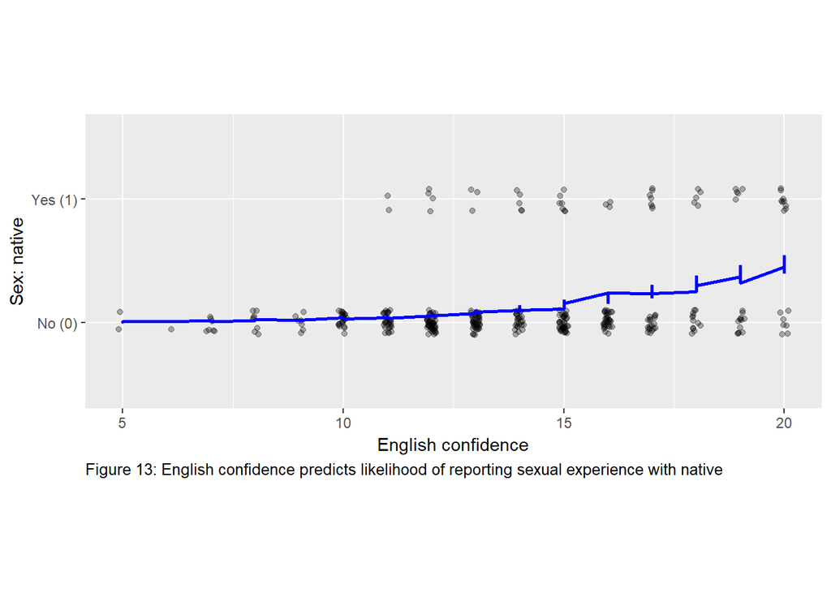

```r
refiltered$prediction_sex_native <- predict(sex_native_glm, newdata = refiltered, type = "response")
ggplot(refiltered, aes(x=english_confidence, y=as.numeric(sex_native)-1)) +
  geom_jitter(width = .1, height = .1, alpha = .3) +
  geom_line(aes(x=english_confidence, y=prediction_sex_native), color = "blue", lwd = 1, lineend="round", linejoin = "mitre") +
  scale_y_discrete(limits = c(0,1), labels = c('No (0)', 'Yes (1)')) +
  theme(aspect.ratio = .4, plot.caption=element_text(hjust=0)) +
  labs(x = "English confidence", y = "Sex: native", caption = "Figure 13: English confidence predicts likelihood of reporting sexual experience with native")
```

```r
htmlreg(list(sex_native_glm, sex_chinese_glm, stress_sex), type = "html",  digits = 3, bold = .05, booktabs = TRUE, sideways = FALSE, use.packages = FALSE, single.row = FALSE, custom.model.names =  c('Sex: native', 'Sex: Chinese', 'Stress'), leading.zero = TRUE, stars = c(0.05, 0.01, 0.001), custom.note = "\\parbox{.4\\linewidth}{\\vspace{2pt}%stars. \\\\Results are as coefficient (standard error).}",  include.nobs = TRUE, include.adjrs = TRUE, include.fstatistic = FALSE, include.rmse = FALSE, include.aic = FALSE, include.loglik = FALSE, include.deviance = FALSE, custom.coef.map = list('(Intercept)' = '(Constant)','english_confidence' = 'English confidence', 'sex_nativeYes' = 'Sex: native', 'sex_chineseYes' = 'Sex: Chinese', 'sexFemale' = 'Gender (Female)', 'traveled_beforeAbroad before' = 'Prior travel'), caption = "The effect of English confidence on sexual experiences and sexual experiences on stress")
```

The effect of English confidence on sexual experiences and sexual experiences on stress

|  | **Sex: native** | **Sex: Chinese** | **Stress** |
| --- | --- | --- | --- |
| (Constant) | **-6.479***** | **-1.198*** | **64.033***** |
|  | (0.960) | (0.603) | (1.878) |
| English confidence | **0.333***** | 0.062 |  |
|  | (0.059) | (0.041) |  |
| Sex: native |  |  | 0.418 |
|  |  |  | (2.556) |
| Sex: Chinese |  |  | 0.880 |
|  |  |  | (2.178) |
| Gender (Female) | -0.378 | **-1.305***** | -1.858 |
|  | (0.338) | (0.263) | (1.930) |
| Prior travel | -0.233 | -0.265 | **-4.297*** |
|  | (0.354) | (0.291) | (1.902) |
| BIC | 273.958 | 384.202 |  |
| Num. obs. | 358 | 358 | 358 |
| R<sup>2</sup> |  |  | 0.018 |
| Adj. R<sup>2</sup> |  |  | 0.007 |

A mediation analysis, shown below, shows only a direct effect of English confidence on stress, i.e., this effect is not mediated by sexual experiences with natives.

```r
refiltered$sex_native_numeric <- as.numeric(refiltered$sex_native) - 1
m <- glm(sex_native_numeric ~ english_confidence + sex, family = "binomial", data = refiltered)
y <- lm(stress ~ english_confidence + sex_native_numeric + sex, data = refiltered)
med_conf_sex_stress <- mediate(m, y, sims = 100, boot = TRUE, mediator = "sex_native_numeric", treat = "english_confidence", control.value = 12, treat.value = 13)
summary(med_conf_sex_stress)
```

```
##
## Causal Mediation Analysis
##
## Nonparametric Bootstrap Confidence Intervals with the Percentile Method
##
##                Estimate 95% CI Lower 95% CI Upper p-value
## ACME             0.1465      -0.0919         0.27    0.42
## ADE             -1.0021      -1.5001        -0.54  <2e-16 ***
## Total Effect    -0.8557      -1.4690        -0.38  <2e-16 ***
## Prop. Mediated  -0.1712      -0.5469         0.15    0.42
## ---
## Signif. codes:  0 '***' 0.001 '**' 0.01 '*' 0.05 '.' 0.1 ' ' 1
##
## Sample Size Used: 358
##
##
## Simulations: 100
```

We’ll next analyze whether duration abroad is associated with stress levels. First we’ll plot the distribution of durations, followed by the stress levels by duration of stay.

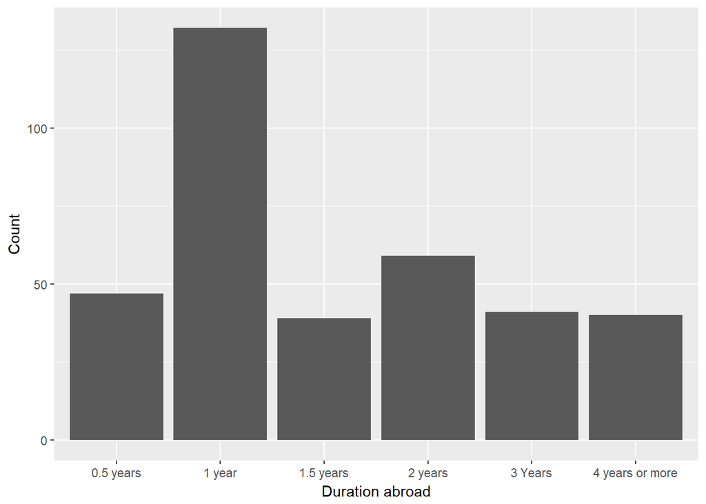

```r
ggplot(refiltered, aes(x=duration)) + geom_histogram(stat="count") + labs(x="Duration abroad", y="Count")
```

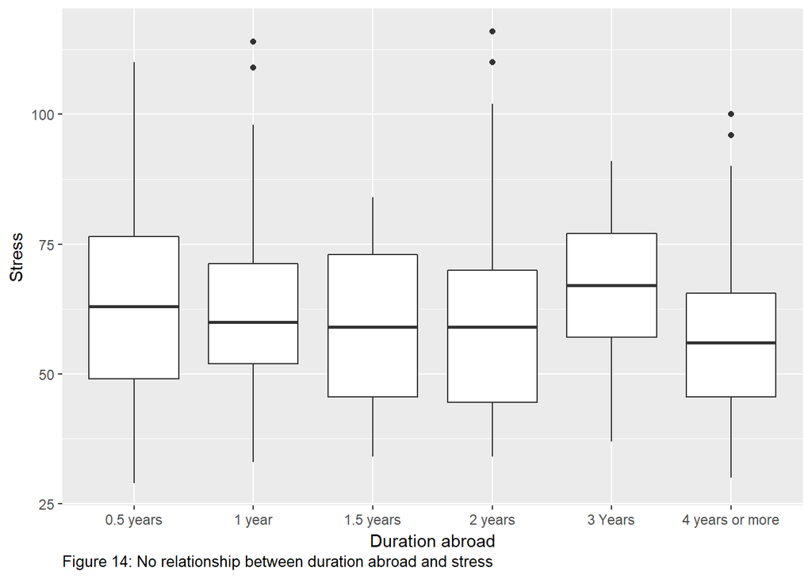

```r
ggplot(refiltered, aes(x=duration, y=stress)) + geom_boxplot() + labs(x="Duration abroad", y="Stress", caption = "Figure 14: No relationship between duration abroad and stress") + theme(plot.caption=element_text(hjust=0))
```

THere’s no clear relationship between duration abroad and stress levels evident in this graph. We’ll run the regressions to confirm this.

```r
Anova(lm(stress ~ duration + sex + traveled_before, data = refiltered), type = "III")
```

```
## Anova Table (Type III tests)
##
## Response: stress
##                 Sum Sq  Df   F value  Pr(>F)
## (Intercept)     387661   1 1452.9433 < 2e-16 ***
## duration          2687   5    2.0143 0.07604 .
## sex                200   1    0.7500 0.38705
## traveled_before   1363   1    5.1081 0.02443 *
## Residuals        93384 350
## ---
## Signif. codes:  0 '***' 0.001 '**' 0.01 '*' 0.05 '.' 0.1 ' ' 1
```

The effect of duration is actually pretty close to statistically significant, which is somewhat surprising. Let’s treat the `duration` as an numeric variable, `duration_numeric`, to see if there’s a linear trend.

```r
duration_model <- lm(stress ~ duration_numeric + sex + traveled_before, data = refiltered)
summary(duration_model)
```

```
##
## Call:
## lm(formula = stress ~ duration_numeric + sex + traveled_before,
##     data = refiltered)
##
## Residuals:
##     Min      1Q  Median      3Q     Max
## -31.993 -11.932  -1.993  10.408  53.856
##
## Coefficients:
##                              Estimate Std. Error t value Pr(>|t|)
## (Intercept)                   65.6727     2.1823  30.094   <2e-16 ***
## duration_numeric              -0.6799     0.8044  -0.845   0.3986
## sexFemale                     -2.1690     1.8583  -1.167   0.2439
## traveled_beforeAbroad before  -4.2962     1.8966  -2.265   0.0241 *
## ---
## Signif. codes:  0 '***' 0.001 '**' 0.01 '*' 0.05 '.' 0.1 ' ' 1
##
## Residual standard error: 16.46 on 354 degrees of freedom
## Multiple R-squared:  0.01943,    Adjusted R-squared:  0.01112
## F-statistic: 2.338 on 3 and 354 DF,  p-value: 0.0733
```

Here we see no evidence of an effect of duration of stay, so taking the above results together, we conclude an absense of a relationship in this dataset. We’ll output a table of this result.

```r
htmlreg(duration_model, type = "html",  digits = 3, bold = .05, booktabs = TRUE, sideways = FALSE, use.packages = FALSE, single.row = FALSE, custom.model.names = "Stress", leading.zero = TRUE, stars = c(0.05, 0.01, 0.001), custom.note = "\\parbox{.4\\linewidth}{\\vspace{2pt}%stars. \\\\Results are as coefficient (standard error).}",  include.nobs = TRUE, include.adjrs = TRUE, include.fstatistic = FALSE, include.rmse = FALSE, custom.coef.map = list('(Intercept)' = '(Constant)', 'duration_numeric' = 'Duration abroad', 'sexFemale' = 'Gender (Female)', 'traveled_beforeAbroad before' = 'Prior travel'), caption = "No relationship between duration abroad and stress was found")
```

No relationship between duration abroad and stress was found

|  | **Stress** |
| --- | --- |
| (Constant) | **65.673***** |
|  | (2.182) |
| Duration abroad | -0.680 |
|  | (0.804) |
| Gender (Female) | -2.169 |
|  | (1.858) |
| Prior travel | **-4.296*** |
|  | (1.897) |
| R<sup>2</sup> | 0.019 |
| Adj. R<sup>2</sup> | 0.011 |
| Num. obs. | 358 |

Finally we’ll do a quick analysis of wealth class. We put ‘extremely wealthy’ into the ‘upper class category’ because there are only 2 ‘extremely wealthly’

```r
wealth_model <- lm(stress ~ wealth_class_no_extreme + sex + traveled_before, data = refiltered)
summary(wealth_model)
```

```
##
## Call:
## lm(formula = stress ~ wealth_class_no_extreme + sex + traveled_before,
##     data = refiltered)
##
## Residuals:
##     Min      1Q  Median      3Q     Max
## -31.791 -11.655  -1.806  10.577  53.473
##
## Coefficients:
##                                           Estimate Std. Error t value
## (Intercept)                                66.9941     5.0069  13.380
## wealth_class_no_extremeLower-middle class   0.1494     5.3007   0.028
## wealth_class_no_extremeMiddle class        -3.2302     4.9113  -0.658
## wealth_class_no_extremeUpper-middle class  -2.1637     5.0643  -0.427
## wealth_class_no_extremeUpper class         -5.7796     6.4289  -0.899
## sexFemale                                  -2.3035     1.8731  -1.230
## traveled_beforeAbroad before               -4.0495     1.9410  -2.086
##                                           Pr(>|t|)
## (Intercept)                                 <2e-16 ***
## wealth_class_no_extremeLower-middle class   0.9775
## wealth_class_no_extremeMiddle class         0.5112
## wealth_class_no_extremeUpper-middle class   0.6695
## wealth_class_no_extremeUpper class          0.3693
## sexFemale                                   0.2196
## traveled_beforeAbroad before                0.0377 *
## ---
## Signif. codes:  0 '***' 0.001 '**' 0.01 '*' 0.05 '.' 0.1 ' ' 1
##
## Residual standard error: 16.48 on 351 degrees of freedom
## Multiple R-squared:  0.02456,    Adjusted R-squared:  0.007884
## F-statistic: 1.473 on 6 and 351 DF,  p-value: 0.1865
```

```r
Anova(wealth_model, type = "III")
```

```
## Anova Table (Type III tests)
##
## Response: stress
##                         Sum Sq  Df  F value  Pr(>F)
## (Intercept)              48649   1 179.0358 < 2e-16 ***
## wealth_class_no_extreme    695   4   0.6391 0.63490
## sex                        411   1   1.5124 0.21960
## traveled_before           1183   1   4.3529 0.03767 *
## Residuals                95376 351
## ---
## Signif. codes:  0 '***' 0.001 '**' 0.01 '*' 0.05 '.' 0.1 ' ' 1
```

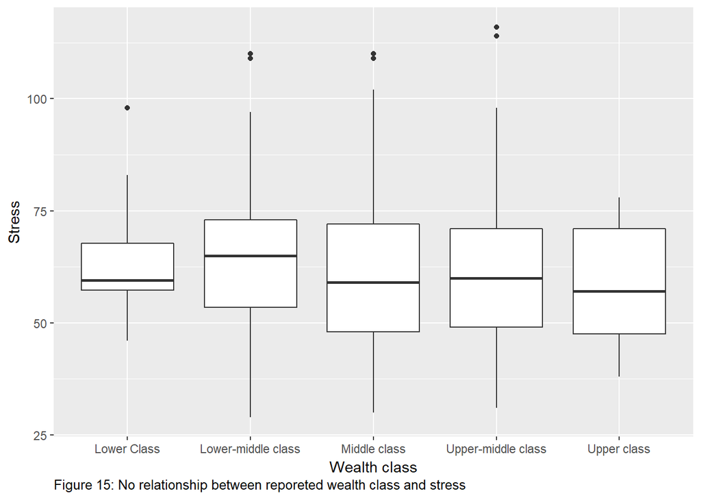

```r
ggplot(refiltered, aes(x=wealth_class_no_extreme, y=stress)) + geom_boxplot() + labs(x="Wealth class", y="Stress", caption = "Figure 15: No relationship between reporeted wealth class and stress") + theme(plot.caption=element_text(hjust=0))
```

```r
htmlreg(wealth_model, type = "html",  digits = 3, bold = .05, booktabs = TRUE, sideways = FALSE, use.packages = FALSE, single.row = FALSE, custom.model.names = "Stress", leading.zero = TRUE, stars = c(0.05, 0.01, 0.001), custom.note = "\\parbox{.4\\linewidth}{\\vspace{2pt}%stars. \\\\Results are as coefficient (standard error).}",  include.nobs = TRUE, include.adjrs = TRUE, include.fstatistic = FALSE, include.rmse = FALSE, custom.coef.map = list('(Intercept)' = '(Constant)', 'wealth_class_no_extremeLower-middle class' = 'Lower-middle - Low', 'wealth_class_no_extremeMiddle class' = 'Middle - Low', 'wealth_class_no_extremeUpper-middle class' = 'Upper-middle - Low', 'wealth_class_no_extremeUpper class' = 'Upper - Low', 'sexFemale' = 'Gender (Female)', 'traveled_beforeAbroad before' = 'Prior travel'), caption = "No relationship between wealth class and stress was found")
```

No relationship between wealth class and stress was found

|  | **Stress** |
| --- | --- |
| (Constant) | **66.994***** |
|  | (5.007) |
| Lower-middle - Low | 0.149 |
|  | (5.301) |
| Middle - Low | -3.230 |
|  | (4.911) |
| Upper-middle - Low | -2.164 |
|  | (5.064) |
| Upper - Low | -5.780 |
|  | (6.429) |
| Gender (Female) | -2.303 |
|  | (1.873) |
| Prior travel | **-4.050*** |
|  | (1.941) |
| R<sup>2</sup> | 0.025 |
| Adj. R<sup>2</sup> | 0.008 |
| Num. obs. | 358 |

The regression output indicated there was an effect of traveled before on stress - a result we’ve seen multiple times before - but it begs the question of whether those with higher incomes have traveled abroad before more in our sample. Let’s do a chisq test to see if that’s the case, and graph the result.

```r
tbl <- table(refiltered$wealth_class_no_extreme, refiltered$traveled_before)
chisq.test(tbl)
```

```
##
##  Pearson's Chi-squared test
##
## data:  tbl
## X-squared = 15.51, df = 4, p-value = 0.003753
```

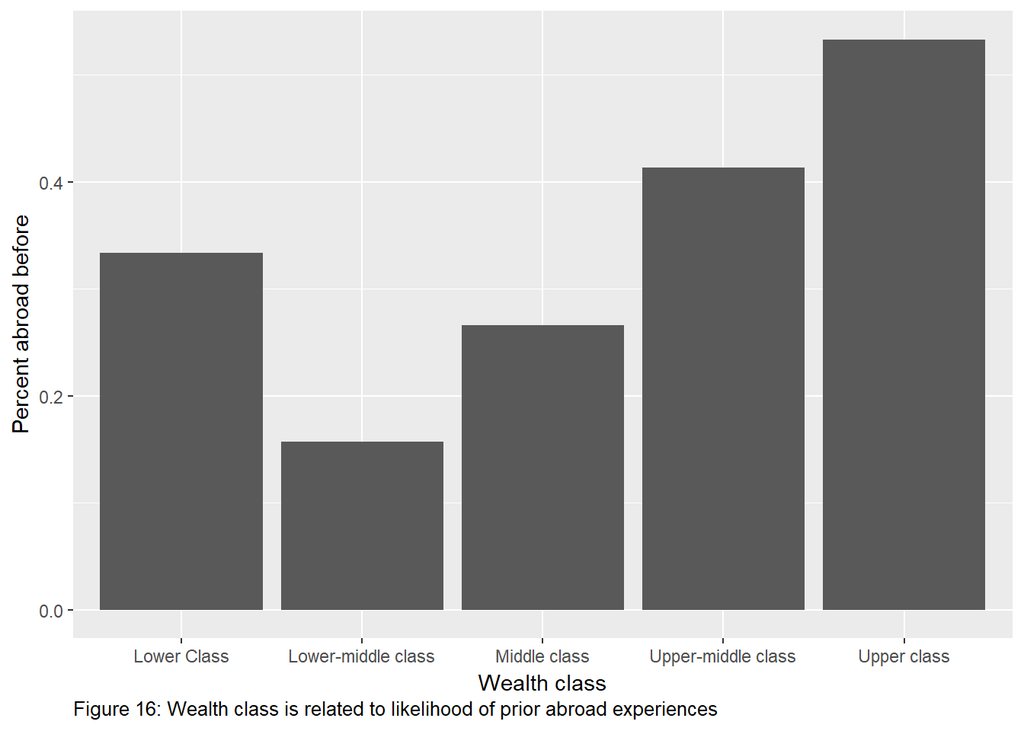

```r
per_abroad_before <-  refiltered %>% group_by(wealth_class_no_extreme) %>% summarise(per = mean(traveled_before == "Abroad before"))
ggplot(per_abroad_before, aes(x=wealth_class_no_extreme, y=per)) + geom_bar(stat="identity") + labs(x="Wealth class", y="Percent abroad before", caption = "Figure 16: Wealth class is related to likelihood of prior abroad experiences") + theme(plot.caption=element_text(hjust=0))
```

## Mixed-models

Next we’ll used a mixed model with data clustered by country where studying took place to look at heterogeneity in the effect of English confidence and test scores on stress.

```r
stressMM <- mixed(stress ~ english_confidence +  sex + traveled_before + (1|country), data = noOtherCountry) # for testing p-value of fixed effect
```

```
## Contrasts set to contr.sum for the following variables: sex, traveled_before, country
```

```
## Numerical variables NOT centered on 0 (i.e., interpretation of all main effects might be difficult if in interactions): english_confidence
```

```
## Fitting one lmer() model.
```

```
## [DONE]
## Calculating p-values.
```

```
## [DONE]
```

```r
stressMMlmer <- lmer(stress ~ english_confidence + sex + traveled_before + (1|country), data = noOtherCountry) # for testing p-value of random effect using RLRT
stressMMscores <- lmer(stress ~ overall_score_numeric_trimmed + sex + traveled_before + (1|country), data = noOtherCountry)

summary(stressMM)
```

```
## Linear mixed model fit by REML ['merModLmerTest']
## Formula:
## stress ~ english_confidence + sex + traveled_before + (1 | country)
##    Data: noOtherCountry
##
## REML criterion at convergence: 2855.1
##
## Scaled residuals:
##      Min       1Q   Median       3Q      Max
## -1.91940 -0.72574 -0.08227  0.66558  3.13859
##
## Random effects:
##  Groups   Name        Variance Std.Dev.
##  country  (Intercept)   3.714   1.927
##  Residual             257.473  16.046
## Number of obs: 341, groups:  country, 6
##
## Fixed effects:
##                    Estimate Std. Error t value
## (Intercept)         73.5568     4.0840  18.011
## english_confidence  -0.9259     0.2814  -3.290
## sex1                 0.6255     0.9417   0.664
## traveled_before1     2.0706     0.9573   2.163
##
## Correlation of Fixed Effects:
##             (Intr) engls_ sex1
## englsh_cnfd -0.947
## sex1         0.023  0.065
## travld_bfr1 -0.179  0.089  0.013
```

```r
print(stressMM)
```

```
## Mixed Model Anova Table (Type 3 tests, KR-method)
##
## Model: stress ~ english_confidence + sex + traveled_before + (1 | country)
## Data: noOtherCountry
##               Effect        df        F p.value
## 1 english_confidence 1, 334.23 10.59 **    .001
## 2                sex 1, 333.51     0.43     .51
## 3    traveled_before 1, 336.48   4.59 *     .03
## ---
## Signif. codes:  0 '***' 0.001 '**' 0.01 '*' 0.05 '+' 0.1 ' ' 1
```

```r
exactRLRT(m=stressMMlmer)
```

```
##
##  simulated finite sample distribution of RLRT.
##
##  (p-value based on 10000 simulated values)
##
## data:
## RLRT = 1.2427, p-value = 0.0925
```

```r
exactRLRT(m=stressMMscores)
```

```
##
##  simulated finite sample distribution of RLRT.
##
##  (p-value based on 10000 simulated values)
##
## data:
## RLRT = 1.1725, p-value = 0.0943
```

A random intercept does not seem to be quite significant - what about a random slope model? or a random intercept + slope (no covariance so we can test 1 random effect at a time with `exactRLRT`)?

```r
MM_RI <- stressMMlmer
MM_RI_RS_nocov <-  lmer(stress ~ english_confidence + sex + traveled_before + (1 + english_confidence||country), data = noOtherCountry)
MM_RS <- lmer(stress ~ english_confidence + sex + traveled_before + (0 + english_confidence|country), data = noOtherCountry)
MM_RS_scores <- lmer(stress ~ overall_score_numeric_trimmed + sex + traveled_before + (0 + overall_score_numeric_trimmed|country), data = noOtherCountry)
exactRLRT(m = MM_RS, mA = MM_RI_RS_nocov, m0 = MM_RI)
```

```
##
##  simulated finite sample distribution of RLRT.
##
##  (p-value based on 10000 simulated values)
##
## data:
## RLRT = 0, p-value = 1
```

```r
exactRLRT(m = MM_RS)
```

```
##
##  simulated finite sample distribution of RLRT.
##
##  (p-value based on 10000 simulated values)
##
## data:
## RLRT = 0.33518, p-value = 0.2122
```

```r
exactRLRT(m = MM_RS_scores)
```

```
##
##  simulated finite sample distribution of RLRT.
##
##  (p-value based on 10000 simulated values)
##
## data:
## RLRT = 0.82673, p-value = 0.1321
```

Neither are significant. Let’s look at the random slope + intercept model anyway. See explanation above - negative correlation between random country intercepts and random slopes for English confidence, indicating that those countries higher stress also showed the most reduction in stress with higher test scores. This is also true for test scores.

```r
MM_RI_RS <- lmer(stress ~ english_confidence + sex + traveled_before + (1 + english_confidence | country), data = noOtherCountry)
summary(MM_RI_RS)
```

```
## Linear mixed model fit by REML t-tests use Satterthwaite approximations
##   to degrees of freedom [lmerMod]
## Formula:
## stress ~ english_confidence + sex + traveled_before + (1 + english_confidence |
##     country)
##    Data: noOtherCountry
##
## REML criterion at convergence: 2849.9
##
## Scaled residuals:
##     Min      1Q  Median      3Q     Max
## -1.9325 -0.6758 -0.0881  0.6605  3.2042
##
## Random effects:
##  Groups   Name               Variance Std.Dev. Corr
##  country  (Intercept)         88.9723  9.4325
##           english_confidence   0.2656  0.5154  -1.00
##  Residual                    254.0125 15.9378
## Number of obs: 341, groups:  country, 6
##
## Fixed effects:
##                              Estimate Std. Error       df t value Pr(>|t|)
## (Intercept)                   74.2812     5.6488   6.3000  13.150 8.29e-06
## english_confidence            -0.7938     0.3513   7.5000  -2.259   0.0557
## sexFemale                     -1.0964     1.8683 333.0000  -0.587   0.5577
## traveled_beforeAbroad before  -4.3763     1.9021 333.8000  -2.301   0.0220
##
## (Intercept)                  ***
## english_confidence           .
## sexFemale
## traveled_beforeAbroad before *
## ---
## Signif. codes:  0 '***' 0.001 '**' 0.01 '*' 0.05 '.' 0.1 ' ' 1
##
## Correlation of Fixed Effects:
##             (Intr) engls_ sexFml
## englsh_cnfd -0.944
## sexFemale   -0.192 -0.043
## trvld_bfrAb -0.031 -0.086  0.016
```

```r
summary(lmer(stress ~ overall_score_numeric_trimmed + sex + traveled_before + (1 + overall_score_numeric_trimmed|country), data = noOtherCountry))
```

```
## Linear mixed model fit by REML t-tests use Satterthwaite approximations
##   to degrees of freedom [lmerMod]
## Formula: stress ~ overall_score_numeric_trimmed + sex + traveled_before +
##     (1 + overall_score_numeric_trimmed | country)
##    Data: noOtherCountry
##
## REML criterion at convergence: 2272.8
##
## Scaled residuals:
##     Min      1Q  Median      3Q     Max
## -1.7813 -0.7304 -0.1726  0.6259  3.0950
##
## Random effects:
##  Groups   Name                          Variance Std.Dev. Corr
##  country  (Intercept)                   1262.84  35.537
##           overall_score_numeric_trimmed   23.39   4.837   -1.00
##  Residual                                282.78  16.816
## Number of obs: 269, groups:  country, 6
##
## Fixed effects:
##                               Estimate Std. Error       df t value
## (Intercept)                    69.1119    18.5681   3.4900   3.722
## overall_score_numeric_trimmed  -0.7719     2.5883   3.1600  -0.298
## sexFemale                      -1.6983     2.2058 258.3900  -0.770
## traveled_beforeAbroad before   -4.5380     2.2426 260.6700  -2.024
##                               Pr(>|t|)
## (Intercept)                     0.0259 *
## overall_score_numeric_trimmed   0.7841
## sexFemale                       0.4420
## traveled_beforeAbroad before    0.0440 *
## ---
## Signif. codes:  0 '***' 0.001 '**' 0.01 '*' 0.05 '.' 0.1 ' ' 1
##
## Correlation of Fixed Effects:
##             (Intr) ovr___ sexFml
## ovrll_scr__ -0.993
## sexFemale   -0.073 -0.008
## trvld_bfrAb  0.031 -0.074  0.011
```